# R Notebook

1 MVP

### Load the diamonds.csv data set and undertake an initial exploration of the data. You will find a description of the meanings of the variables on the relevant [Kaggle page](https://www.kaggle.com/shivam2503/diamonds/)

```r
library(tidyverse)
library(mosaic)
library(mosaicData)
library(ggfortify)
library(GGally)
library(fastDummies)

diamonds <- read_csv("data/diamonds.csv")
```

### We expect the carat of the diamonds to be strong correlated with the physical dimensions x, y and z. Use ggpairs() to investigate correlations between these four variables.

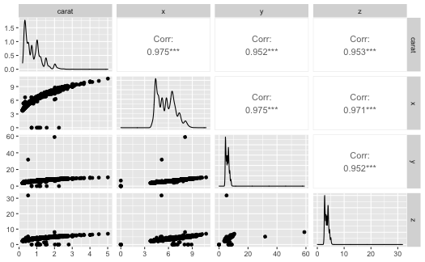

```r
diamonds %>%
  ggpairs(columns = c("carat", "x", "y", "z")
  )
```

```r
# there is a very strong correlation between the carat and the physical dimensions (x, y and z) (and also price)
```

### So, we do find significant correlations. Let’s drop columns x, y and z from the dataset, in preparation to use only carat going forward.

```r
diamonds <- diamonds %>%
  select(-c(x, y, z))
```

### We are interested in developing a regression model for the price of a diamond in terms of the possible predictor variables in the dataset.

### Use ggpairs() to investigate correlations between price and the predictors (this may take a while to run, don’t worry, make coffee or something).

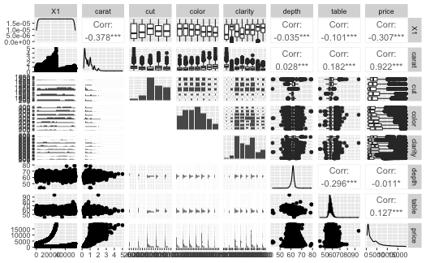

### Perform further ggplot visualisations of any significant correlations you find.

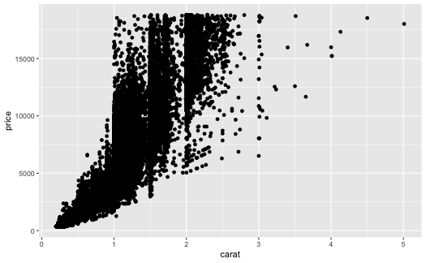

### Shortly we may try a regression fit using one or more of the categorical predictors cut, clarity and color, so let’s investigate these predictors:

### Investigate the factor levels of these predictors. How many dummy variables do you expect for each of them?

```r
unique(diamonds$cut)
```

```
[1] "Ideal"     "Premium"   "Good"      "Very Good" "Fair"
```

```r
unique(diamonds$clarity)
```

```
[1] "SI2"  "SI1"  "VS1"  "VS2"  "VVS2" "VVS1" "I1"   "IF"
```

```r
unique(diamonds$color)
```

```
[1] "E" "I" "J" "H" "F" "G" "D"
```

### Use the dummy_cols() function in the fastDummies package to generate dummies for these predictors and check the number of dummies in each case.

```r
diamonds %>%
  dummy_cols(select_columns = c("cut", "clarity", "color"),
             remove_first_dummy = TRUE,
             remove_selected_columns = TRUE)
```

| X1 | carat | depth | table | price | cut_Good | cut_Ideal | cut_Premium | cut_Very Good | clarity_IF | clarity_SI1 | clarity_SI2 | clarity_VS1 | clarity_VS2 | clarity_VVS1 | clarity_VVS2 | color_E | color_F | color_G | color_H | color_I | color_J |
| --- | --- | --- | --- | --- | --- | --- | --- | --- | --- | --- | --- | --- | --- | --- | --- | --- | --- | --- | --- | --- | --- |
| 1 | 0.23 | 61.5 | 55.0 | 326 | 0 | 1 | 0 | 0 | 0 | 0 | 1 | 0 | 0 | 0 | 0 | 1 | 0 | 0 | 0 | 0 | 0 |
| 2 | 0.21 | 59.8 | 61.0 | 326 | 0 | 0 | 1 | 0 | 0 | 1 | 0 | 0 | 0 | 0 | 0 | 1 | 0 | 0 | 0 | 0 | 0 |
| 3 | 0.23 | 56.9 | 65.0 | 327 | 1 | 0 | 0 | 0 | 0 | 0 | 0 | 1 | 0 | 0 | 0 | 1 | 0 | 0 | 0 | 0 | 0 |
| 4 | 0.29 | 62.4 | 58.0 | 334 | 0 | 0 | 1 | 0 | 0 | 0 | 0 | 0 | 1 | 0 | 0 | 0 | 0 | 0 | 0 | 1 | 0 |
| 5 | 0.31 | 63.3 | 58.0 | 335 | 1 | 0 | 0 | 0 | 0 | 0 | 1 | 0 | 0 | 0 | 0 | 0 | 0 | 0 | 0 | 0 | 1 |
| 6 | 0.24 | 62.8 | 57.0 | 336 | 0 | 0 | 0 | 1 | 0 | 0 | 0 | 0 | 0 | 0 | 1 | 0 | 0 | 0 | 0 | 0 | 1 |
| 7 | 0.24 | 62.3 | 57.0 | 336 | 0 | 0 | 0 | 1 | 0 | 0 | 0 | 0 | 0 | 1 | 0 | 0 | 0 | 0 | 0 | 1 | 0 |
| 8 | 0.26 | 61.9 | 55.0 | 337 | 0 | 0 | 0 | 1 | 0 | 1 | 0 | 0 | 0 | 0 | 0 | 0 | 0 | 0 | 1 | 0 | 0 |
| 9 | 0.22 | 65.1 | 61.0 | 337 | 0 | 0 | 0 | 0 | 0 | 0 | 0 | 0 | 1 | 0 | 0 | 1 | 0 | 0 | 0 | 0 | 0 |
| 10 | 0.23 | 59.4 | 61.0 | 338 | 0 | 0 | 0 | 1 | 0 | 0 | 0 | 1 | 0 | 0 | 0 | 0 | 0 | 0 | 1 | 0 | 0 |

[output cut: 990 more lines]